# Evaluating Differences in Dam Counts

And Their Effects on Abundance Estimates

Kevin See<sup>1,✉</sup>, and Ben Truscott<sup>1</sup>

September 29, 2022

<sup>1</sup> Washington Department of Fish & Wildlife

<sup>✉</sup> Correspondence: Kevin See <Kevin.See@dfw.wa.gov>

# 1 Introduction

The **D**am **A**dult **B**ranch **O**ccupancy **M**odel (DABOM) has been used to estimate steelhead escapement to various locations around the Upper Columbia for nearly a decade. One of the requirements of this model is an accurate estimate of abundance (possibly with uncertainty) *somewhere* in the system. To this point, we have used dam counts at Priest Rapids Dam to generate that estimate of abundance. We have adjusted the raw counts by an estimated re-ascension rate, to account for fish that may have been counted twice.

Recently, we have called into question the assumption that the dam counts at Priest Rapids are an accurate depiction of how many steelhead are crossing that dam each day. One reason for this questioning is a comparison between the counts at Priest Rapids, and other upstream dams (i.e Rock Island, Rocky Reach and Wells) (Table 1.1). In recent years (2019-2022) the counts were higher at Rock Island dam, the next upstream dam, compared to Priest Rapids, which is surprising because there are no major tributaries between Priest Rapids and Rock Island. Between Rock Island and Rocky Reach some steelhead move into the Wenatchee River, and between Rocky Reach and Wells dam some move into the Entiat River, so we expect those counts to shrink as we move upstream.

It is important to acknowledge the various processes going on at and between each dam to help understand these discrepancies. First, although the tagged fish at Priest are assumed to be a representative sample of the steelhead run at large crossing Priest, the proportion of hatchery and natural origin fish may be different at different dams as fish move into different populations at different rates depending on their origin. Second, the re-ascension rate may be (and probably is) different at other dams compared to Priest. We have recently begun evaluating re-ascension rates at Rock Island and Rocky Reach, as well as Priest Rapids, but those rates are not available for all years yet.

Table 1.1: Total steelhead dam counts at mainstem dams on the Columbia River from June 1 of the previous year to May 31 (or the most recent day available in 2022), and the percent of those counts compared to counts at Priest Rapids Dam.

| Year | Priest Rapids | Rock Island | Rocky Reach | Wells |
| --- | --- | --- | --- | --- |
| 2011 | 26,431 (100%) | 22,129 (83.7%) | 18,091 (68.4%) | 12,791 (48.4%) |
| 2012 | 20,806 (100%) | 19,123 (91.9%) | 15,418 (74.1%) | 12,047 (57.9%) |
| 2013 | 17,192 (100%) | 15,387 (89.5%) | 12,529 (72.9%) | 9,741 (56.7%) |
| 2014 | 15,072 (100%) | 11,675 (77.5%) | 9,293 (61.7%) | 7,280 (48.3%) |
| 2015 | 19,659 (100%) | 14,883 (75.7%) | 10,450 (53.2%) | 7,650 (38.9%) |
| 2016 | 14,303 (100%) | 13,962 (97.6%) | 10,871 (76%) | 9,165 (64.1%) |
| 2017 | 6,507 (100%) | 7,182 (110.4%) | 5,762 (88.6%) | 4,820 (74.1%) |
| 2018 | 5,804 (100%) | 5,269 (90.8%) | 3,951 (68.1%) | 3,835 (66.1%) |
| 2019 | 4,909 (100%) | 5,244 (106.8%) | 4,283 (87.2%) | 3,912 (79.7%) |
| 2020 | 3,911 (100%) | 4,441 (113.6%) | 3,333 (85.2%) | 2,763 (70.6%) |
| 2021 | 6,509 (100%) | 6,734 (103.5%) | 5,397 (82.9%) | 4,391 (67.5%) |
| 2022 | 2,810 (100%) | 4,528 (161.1%) | 3,989 (142%) | 3,116 (110.9%) |
| 2023 | 3,720 (100%) | 5,665 (152.3%) | 4,374 (117.6%) | 2,835 (76.2%) |

# 2 Methods

We completed the same analysis for each spawn year between 2011 and 2021. For each dam (Rock Island, Rocky Reach, and Wells), we started by examining all the tags put out at Priest Rapids that were observed at or upstream of the $j^{th}$ dam, by origin ($i$). For each dam, we used these groups of tags to estimate the proportion of each origin of fish that crossed each dam ($\pi_{i,j}$).

$$\pi_{i,j} = \frac{t^{up}_{i,j}}{\sum{t^{up}_j}}$$

We then examined the number of Priest tags detected at each dam (prior to cleaning the detection data with PITcleanr), separated by origin. We inflated this number by the estimated detection probability estimated for each dam by DABOM ($\hat{p}_j$) to generate an estimate of the number of tags that crossed each dam. We then divided this estimate by the total number of tags, by origin, that we started with at Priest. This provides an estimate of the probability that a fish would move from Priest past the $j^{th}$ dam, by origin $i$ ($\psi_{i,j}$).

$$t^{est}_{i,j} = \frac{t^{obs}_{i,j}}{\hat{p}_j} \\
\psi_{i,j} = \frac{t^{est}_{i,j}}{t^{PRD}_i}$$

Through a collaboration with the Columbia Basin Research group, a query was constructed from PIT tag detections in PTAGIS to evaluate whether each tag detected at a dam was a first-time crossing, or a re-ascension (the fish had fallen back below the dam and was crossing it again). We used this query to generate estimates of re-ascension rates for origin $i$ at dam $j$ ($\eta_{i,j}$). The re-ascension queries are currently available for Priest Rapids (all years), Rock Island (2016 - 2021) and Rocky Reach (2015 - 2021). For Rock Island and Rocky Reach, for years when the specific rate was not available we used the mean across the years we did have. For other dams (i.e. Wells), we used the re-ascension rate at Priest Rapids for that year.

The next step was to multiply the total dam counts at each dam ($C_j$) by the estimated proportion of origins ($\pi_{i,j}$) and one minus the re-ascention rate ($1 - \eta_{i,j}$), then divide each result by the appropriate movement probability ($\psi_{i,j}$). This provides as estimate of the total number of unique fish, by origin, that crossed Priest, according to the dam count at each dam ($\Gamma_{i,j}$). Using the delta method, the appropriate uncertainty was propagated through this entire process.

$$\Gamma_{i,j} = \frac{C_j * \pi_{i,j} * (1 - \eta_{i,j})}{\psi_{i,j}} \\
\Gamma_j = \sum_i{\Gamma_{i,j}}$$
These estimates can be inflated by the re-ascension rate at Priest Rapids and summed across origin to compare to the recorded counts of total steelhead at Priest Rapids. They can also be used to calculate the effect of using different dam counts within DABOM on steelhead escapement estimates across the entire Upper Columbia by origin and year.

# 3 Results

The estimated parameters used in the overall calculations are shown in Table 3.1. The resulting estimates of Priest Dam count equivalents are in Table 3.2, and also presented visually in Figure 3.2. The absolute difference in estimates of unique fish crossing Priest Rapids Dam compared to using counts at Priest, split by origin, is shown in Figure 3.3. The relative impacts to DABOM estimates of abundance from using a different abundance estimate at Priest Rapids, compared to the original estimate, are shown in Figure 3.4 and Table 3.3. The average relative difference across an early period (2011-2015) and a late period is shown in Table 3.4.

Table 3.1: Estimated parameters used as inputs for Priest Rapids Dam count equivalents.

| Year | Dam | Origin | $\pi$ | $\eta$ | $\psi$ | Total Dam Count (C) |
| --- | --- | --- | --- | --- | --- | --- |
| 2011 | Priest Rapids | H | 0.712 | 0.050 | 1.000 | 26,431 |
| 2011 | Rock Island | H | 0.739 | 0.050 | 0.883 | 22,129 |
| 2011 | Rocky Reach | H | 0.801 | 0.050 | 0.769 | 18,091 |
| 2011 | Wells | H | 0.818 | 0.050 | 0.617 | 12,791 |
| 2011 | Priest Rapids | W | 0.288 | 0.039 | 1.000 | 26,431 |
| 2011 | Rock Island | W | 0.261 | 0.039 | 0.787 | 22,129 |
| 2011 | Rocky Reach | W | 0.199 | 0.039 | 0.471 | 18,091 |
| 2011 | Wells | W | 0.182 | 0.039 | 0.338 | 12,791 |
| 2012 | Priest Rapids | H | 0.763 | 0.052 | 1.000 | 20,806 |
| 2012 | Rock Island | H | 0.764 | 0.052 | 0.850 | 19,123 |
| 2012 | Rocky Reach | H | 0.824 | 0.052 | 0.732 | 15,418 |
| 2012 | Wells | H | 0.837 | 0.052 | 0.628 | 12,047 |
| 2012 | Priest Rapids | W | 0.237 | 0.038 | 1.000 | 20,806 |
| 2012 | Rock Island | W | 0.236 | 0.038 | 0.858 | 19,123 |
| 2012 | Rocky Reach | W | 0.176 | 0.038 | 0.502 | 15,418 |
| 2012 | Wells | W | 0.163 | 0.038 | 0.393 | 12,047 |
| 2013 | Priest Rapids | H | 0.809 | 0.064 | 1.000 | 17,192 |
| 2013 | Rock Island | H | 0.810 | 0.064 | 0.855 | 15,387 |
| 2013 | Rocky Reach | H | 0.864 | 0.064 | 0.741 | 12,529 |
| 2013 | Wells | H | 0.873 | 0.064 | 0.632 | 9,741 |
| 2013 | Priest Rapids | W | 0.191 | 0.070 | 1.000 | 17,192 |
| 2013 | Rock Island | W | 0.190 | 0.070 | 0.844 | 15,387 |
| 2013 | Rocky Reach | W | 0.136 | 0.070 | 0.495 | 12,529 |
| 2013 | Wells | W | 0.127 | 0.070 | 0.387 | 9,741 |
| 2014 | Priest Rapids | H | 0.650 | 0.080 | 1.000 | 15,072 |
| 2014 | Rock Island | H | 0.642 | 0.080 | 0.788 | 11,675 |
| 2014 | Rocky Reach | H | 0.689 | 0.080 | 0.650 | 9,293 |
| 2014 | Wells | H | 0.700 | 0.080 | 0.584 | 7,280 |
| 2014 | Priest Rapids | W | 0.350 | 0.074 | 1.000 | 15,072 |
| 2014 | Rock Island | W | 0.358 | 0.074 | 0.816 | 11,675 |

[output cut: 58 more lines]

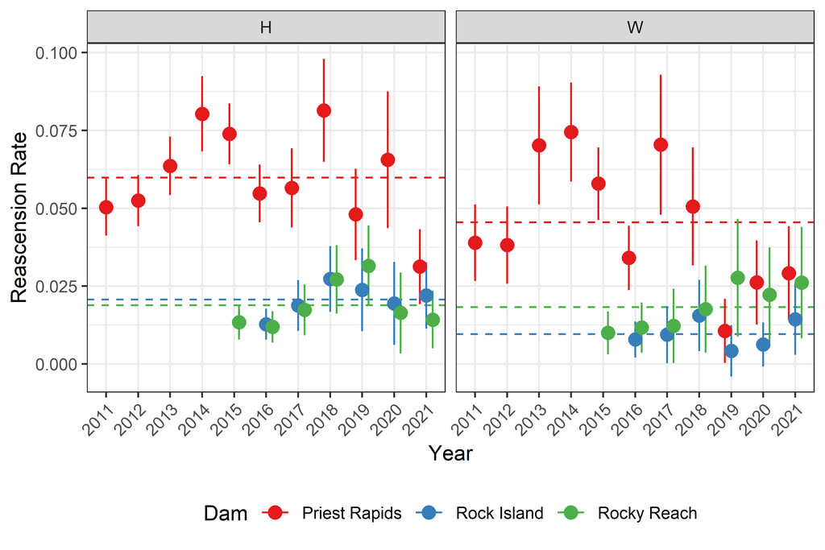

Figure 3.1: Estimates of re-ascension rates, colored by dam, with 95% confidence intervals, faceted by origin. Dashed lines represent mean rates across all years that are available.

Table 3.2: Estimates of the equivalent of total counts at Priest Rapids dam, and the relative difference compared to counts at Priest that year.

Year

Dam

Re-Ascension Available

Priest Count Equiv.

SE Count

Relative Difference (%)

SE Rel. Diff.

2011

Priest Rapids

TRUE

26,431

0.0

2011

Rock Island

FALSE

25,795

418

-2.4

1.6

2011

Rocky Reach

FALSE

487

0.0

1.8

2011

Wells

FALSE

23,792

502

-10.0

1.9

2012

Priest Rapids

TRUE

20,806

0.0

2012

Rock Island

FALSE

22,394

316

7.6

1.5

2012

Rocky Reach

FALSE

22,702

351

9.1

1.7

2012

Wells

FALSE

21,000

356

0.9

1.7

2013

Priest Rapids

TRUE

17,192

0.0

2013

Rock Island

FALSE

17,957

303

4.4

1.8

2013

Rocky Reach

FALSE

17,972

286

4.5

1.7

2013

Wells

FALSE

16,572

285

-3.6

1.7

2014

Priest Rapids

TRUE

15,072

0.0

2014

Rock Island

FALSE

14,548

268

-3.5

1.8

2014

Rocky Reach

FALSE

15,087

302

0.1

2.0

2014

Wells

FALSE

13,356

283

-11.4

1.9

2015

Priest Rapids

TRUE

19,659

0.0

2015

Rock Island

FALSE

18,724

318

-4.8

1.6

2015

Rocky Reach

TRUE

19,481

311

-0.9

1.6

2015

Wells

FALSE

15,904

283

-19.1

1.4

2016

Priest Rapids

TRUE

14,303

0.0

2016

Rock Island

TRUE

16,817

245

17.6

1.7

2016

Rocky Reach

TRUE

16,132

258

12.8

1.8

2016

Wells

FALSE

14,434

251

0.9

1.8

2017

Priest Rapids

TRUE

6,507

0.0

2017

Rock Island

TRUE

8,860

166

36.2

2.5

2017

Rocky Reach

TRUE

8,339

167

28.2

2.6

2017

Wells

FALSE

7,328

158

12.6

2.4

2018

Priest Rapids

TRUE

5,804

0.0

2018

Rock Island

TRUE

6,137

135

5.7

2.3

2018

Rocky Reach

TRUE

5,721

138

-1.4

2.4

2018

Wells

FALSE

5,788

149

-0.3

2.6

2019

Priest Rapids

TRUE

4,909

0.0

2019

Rock Island

TRUE

6,283

185

28.0

3.8

2019

Rocky Reach

TRUE

5,751

141

17.2

2.9

2019

Wells

FALSE

5,760

150

17.3

3.1

2020

Priest Rapids

TRUE

3,911

0.0

2020

Rock Island

TRUE

5,193

145

32.8

3.7

2020

Rocky Reach

TRUE

4,853

152

24.1

3.9

2020

Wells

FALSE

4,396

148

12.4

3.8

2021

Priest Rapids

TRUE

6,509

0.0

2021

Rock Island

TRUE

7,688

195

18.1

3.0

2021

Rocky Reach

TRUE

7,712

220

18.5

3.4

2021

Wells

FALSE

6,960

216

6.9

3.3

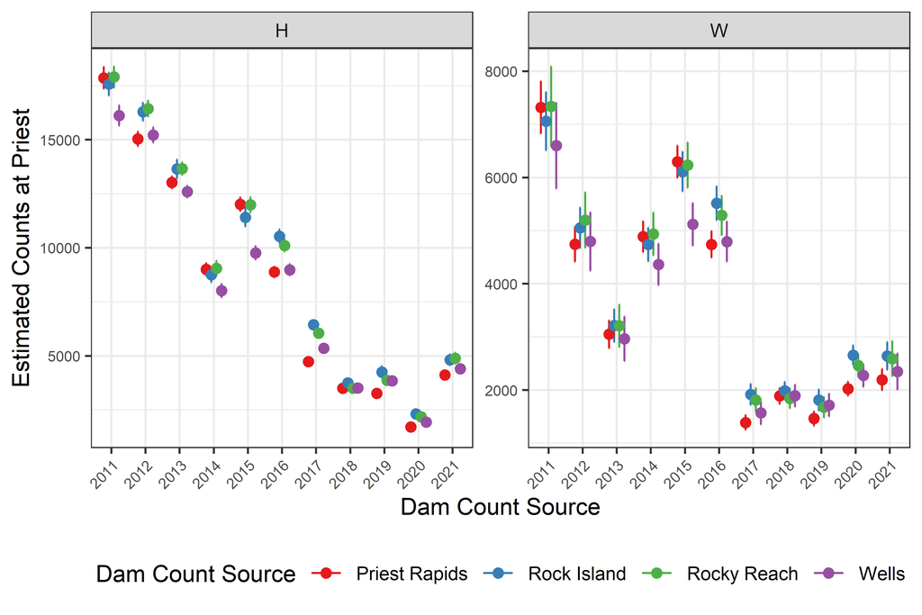

Figure 3.2: Estimates of unique number of fish crossing Priest Rapids dam, based on counts from different dams (colors). Facted by origin. Errorbars represent 95% confidence intervals.

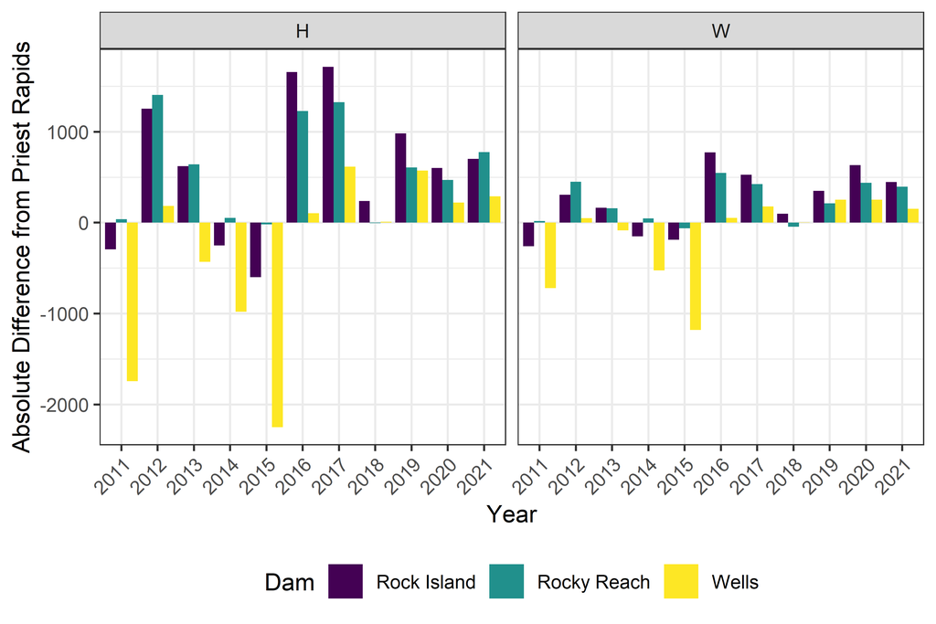

Figure 3.3: Absolute differences of the equivalent of total steelhad counts at Priest Rapids Dam, compared to using counts at Priest Rapids, using starting counts from different dams (colors), faceted by origin.

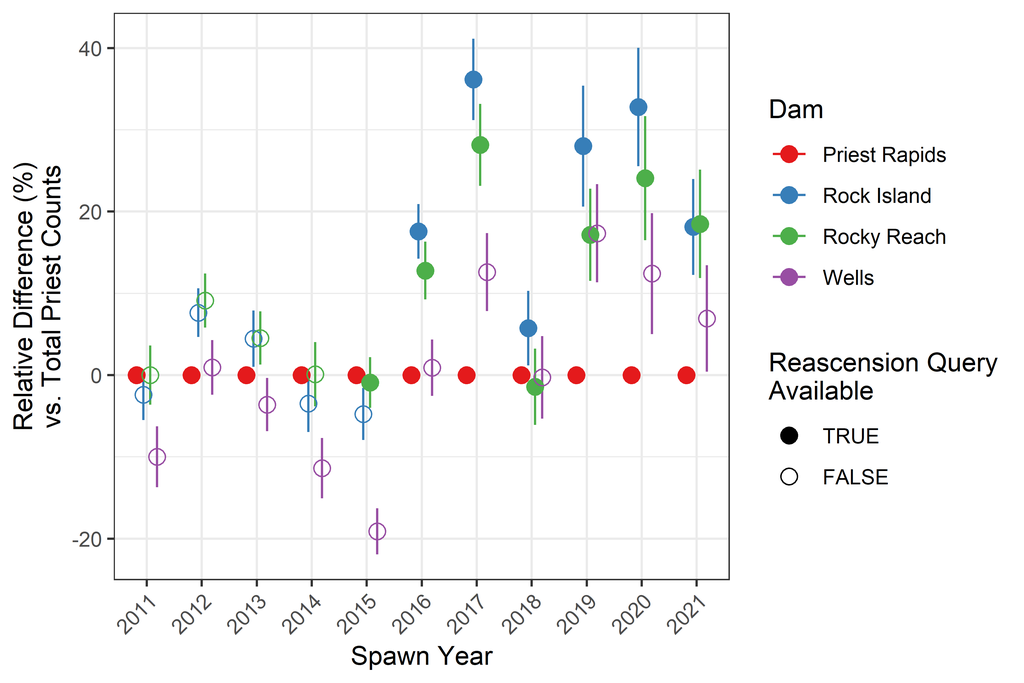

Figure 3.4: Relative differences of the equivalent of total steelhad counts at Priest Rapids Dam, using starting counts from different dams (colors), with 95% confidence intervals. The shape of each point depicts whether re-ascension data was available for that dam/year combination.

Table 3.3: Comparison between using original estimate of escapement at Priest by origin with Priest equivalents from various dams. Relative difference would impact all abundance estimates from DABOM equally.

| Year | Dam | Origin | Priest Equiv. | SE | Orginal Priest Est. | Relative Difference (%) |
| --- | --- | --- | --- | --- | --- | --- |
| 2011 | Rock Island | H | 17,575 | 272 | 17,868 | -1.6 |
| 2011 | Rock Island | W | 7,061 | 281 | 7,319 | -3.5 |
| 2011 | Rocky Reach | H | 17,906 | 249 | 17,868 | 0.2 |
| 2011 | Rocky Reach | W | 7,337 | 384 | 7,319 | 0.2 |
| 2011 | Wells | H | 16,124 | 237 | 17,868 | -9.8 |
| 2011 | Wells | W | 6,600 | 412 | 7,319 | -9.8 |
| 2012 | Rock Island | H | 16,293 | 219 | 15,039 | 8.3 |
| 2012 | Rock Island | W | 5,053 | 195 | 4,746 | 6.5 |
| 2012 | Rocky Reach | H | 16,444 | 193 | 15,039 | 9.3 |
| 2012 | Rocky Reach | W | 5,197 | 266 | 4,746 | 9.5 |
| 2012 | Wells | H | 15,223 | 185 | 15,039 | 1.2 |
| 2012 | Wells | W | 4,796 | 279 | 4,746 | 1.0 |
| 2013 | Rock Island | H | 13,649 | 226 | 13,027 | 4.8 |
| 2013 | Rock Island | W | 3,214 | 158 | 3,050 | 5.4 |
| 2013 | Rocky Reach | H | 13,668 | 158 | 13,027 | 4.9 |
| 2013 | Rocky Reach | W | 3,209 | 205 | 3,050 | 5.2 |
| 2013 | Wells | H | 12,595 | 146 | 13,027 | -3.3 |
| 2013 | Wells | W | 2,966 | 214 | 3,050 | -2.7 |
| 2014 | Rock Island | H | 8,752 | 178 | 9,003 | -2.8 |
| 2014 | Rock Island | W | 4,740 | 162 | 4,889 | -3.1 |
| 2014 | Rocky Reach | H | 9,055 | 179 | 9,003 | 0.6 |
| 2014 | Rocky Reach | W | 4,937 | 206 | 4,889 | 1.0 |
| 2014 | Wells | H | 8,023 | 163 | 9,003 | -10.9 |
| 2014 | Wells | W | 4,364 | 198 | 4,889 | -10.7 |
| 2015 | Rock Island | H | 11,416 | 220 | 12,015 | -5.0 |
| 2015 | Rock Island | W | 6,110 | 191 | 6,298 | -3.0 |
| 2015 | Rocky Reach | H | 11,997 | 181 | 12,015 | -0.1 |
| 2015 | Rocky Reach | W | 6,236 | 219 | 6,298 | -1.0 |
| 2015 | Wells | H | 9,766 | 160 | 12,015 | -18.7 |
| 2015 | Wells | W | 5,119 | 206 | 6,298 | -18.7 |
| 2016 | Rock Island | H | 10,536 | 159 | 8,880 | 18.7 |
| 2016 | Rock Island | W | 5,516 | 163 | 4,742 | 16.3 |
| 2016 | Rocky Reach | H | 10,109 | 149 | 8,880 | 13.8 |
| 2016 | Rocky Reach | W | 5,289 | 191 | 4,742 | 11.5 |
| 2016 | Wells | H | 8,984 | 136 | 8,880 | 1.2 |
| 2016 | Wells | W | 4,794 | 194 | 4,742 | 1.1 |
| 2017 | Rock Island | H | 6,442 | 109 | 4,729 | 36.2 |
| 2017 | Rock Island | W | 1,918 | 102 | 1,390 | 38.1 |
| 2017 | Rocky Reach | H | 6,055 | 98 | 4,729 | 28.1 |
| 2017 | Rocky Reach | W | 1,813 | 115 | 1,390 | 30.5 |
| 2017 | Wells | H | 5,345 | 93 | 4,729 | 13.0 |
| 2017 | Wells | W | 1,570 | 110 | 1,390 | 13.0 |
| 2018 | Rock Island | H | 3,743 | 88 | 3,504 | 6.8 |
| 2018 | Rock Island | W | 1,988 | 84 | 1,888 | 5.3 |
| 2018 | Rocky Reach | H | 3,500 | 80 | 3,504 | -0.1 |
| 2018 | Rocky Reach | W | 1,843 | 96 | 1,888 | -2.4 |
| 2018 | Wells | H | 3,513 | 87 | 3,504 | 0.2 |
| 2018 | Wells | W | 1,893 | 106 | 1,888 | 0.2 |
| 2019 | Rock Island | H | 4,248 | 142 | 3,266 | 30.1 |
| 2019 | Rock Island | W | 1,812 | 103 | 1,463 | 23.9 |
| 2019 | Rocky Reach | H | 3,872 | 90 | 3,266 | 18.6 |
| 2019 | Rocky Reach | W | 1,675 | 100 | 1,463 | 14.5 |
| 2019 | Wells | H | 3,841 | 93 | 3,266 | 17.6 |
| 2019 | Wells | W | 1,717 | 109 | 1,463 | 17.4 |
| 2020 | Rock Island | H | 2,314 | 95 | 1,712 | 35.1 |
| 2020 | Rock Island | W | 2,658 | 95 | 2,025 | 31.3 |
| 2020 | Rocky Reach | H | 2,183 | 91 | 1,712 | 27.5 |
| 2020 | Rocky Reach | W | 2,462 | 110 | 2,025 | 21.6 |
| 2020 | Wells | H | 1,933 | 85 | 1,712 | 12.9 |
| 2020 | Wells | W | 2,277 | 111 | 2,025 | 12.5 |
| 2021 | Rock Island | H | 4,817 | 131 | 4,115 | 17.1 |
| 2021 | Rock Island | W | 2,643 | 132 | 2,195 | 20.4 |
| 2021 | Rocky Reach | H | 4,893 | 128 | 4,115 | 18.9 |
| 2021 | Rocky Reach | W | 2,591 | 168 | 2,195 | 18.0 |
| 2021 | Wells | H | 4,404 | 112 | 4,115 | 7.0 |
| 2021 | Wells | W | 2,349 | 174 | 2,195 | 7.0 |

Table 3.4: Mean relative difference (%) between escapement estimates using counts from these dams compared to Priest Rapids, by origin, separated into an early period (2011-2015) and late period (2016-2021).

| Dam | Origin | Early | Late |
| --- | --- | --- | --- |
| Rock Island | H | 0.74 | 24.00 |
| Rock Island | W | 0.45 | 22.55 |
| Rocky Reach | H | 2.98 | 17.79 |
| Rocky Reach | W | 2.99 | 15.63 |
| Wells | H | -8.29 | 8.67 |
| Wells | W | -8.20 | 8.53 |

# 4 Discussion

In recent years, there appears to be some discrepancy between dam counts of steelhead at Priest Rapids dam, and those further upstream, particularly Rock Island and Rocky Reach. Focusing on Rock Island, the average differences have shifted from less than 1% in 2011-2015 to more than 20% in recent years (2016-2021). The choice of using counts at Priest Rapids or Rock Island will have a substantial impact on estimates of escapement throughout the Upper Columbia.

Counts at Rock Island and Rocky Reach dams are overseen by Chelan County Public Utility District (PUD), while Grant County PUD is in charge of counts at Priest Rapids Dam, and Douglas County PUD runs the counts at Wells Dam. There is a lot of consistency between Rock Island and Rocky Reach estimates (Figures 3.2 and 3.4), suggesting operations at each dam may explain at least part of the differences between estimates.